# DATA 606 Data Project Proposal

Shawn Ganz

### Data Preparation

```r
# load data
library(tidyverse)
library(ggplot2)
library(infer)
library(haven)

df <- read_xpt("https://wwwn.cdc.gov/Nchs/Data/Nhanes/Public/2021/DataFiles/DR1TOT_L.xpt") |>
  select(day_of_week = DR1DAY,
         recall_status = DR1DRSTZ,
         total_kcal = DR1TKCAL) |>
  filter(recall_status == 1, day_of_week %in% 1:7) |>
  mutate(weekend = ifelse(day_of_week %in% c(1, 7), "weekend", "weekday"))

glimpse(df)
```

### Research question

**Among NHANES 2021–2023 participants with a reliable Day 1 dietary recall, is mean total daily energy intake different between weekday and weekend intake days**

### Cases

**Each case represents one NHANES participant, 6,694 cases after filtering for the project proposal.**

### Data collection

**The data was collected as part of the NHANES dietary interview component, “What We Eat in America” for August 2021-August 2023 cycle. The objective of the dietary interview component is to obtain detailed dietary intake information from NHANES participants.**

### Type of study

**This is an observational study. NHANES measures what participants reported consuming; it does not assign diets or treatments.**

### Data Source

**National Center for Health Statistics (NCHS). National Health and Nutrition Examination Survey: August 2021–August 2023 Dietary Interview – Total Nutrient Intakes, First Day (DR1TOT_L), dataset, [dataset information](https://wwwn.cdc.gov/Nchs/Data/Nhanes/Public/2021/DataFiles/DR1TOT_L.htm), [study information](https://wwwn.cdc.gov/nchs/nhanes/search/datapage.aspx?Component=Dietary&Cycle=2021-2023) .**

### Describe your variables?

**`day_of_week`: qualitative (categorical), derives two categorical (weekday or weekend) based off `DR1DAY`, which codes the intake day as Sunday through Saturday. `recall_status`: qualitative (categorical). This comes from `DR1DRSTZ`, where 1 means the dietary recall was reliable and met NHANES minimum criteria. `total_kcal`: quantitative. This comes from `DR1TKCAL`, total daily energy intake measured in kilocalories. The dependent variable is `total_kcal` and the explanatory variable is `weekend`.**

### Relevant summary statistics

**Provide summary statistics for each the variables. Also include appropriate visualizations related to your research question (e.g. scatter plot, boxplots, etc). This step requires the use of R, hence a code chunk is provided below. Insert more code chunks as needed.**

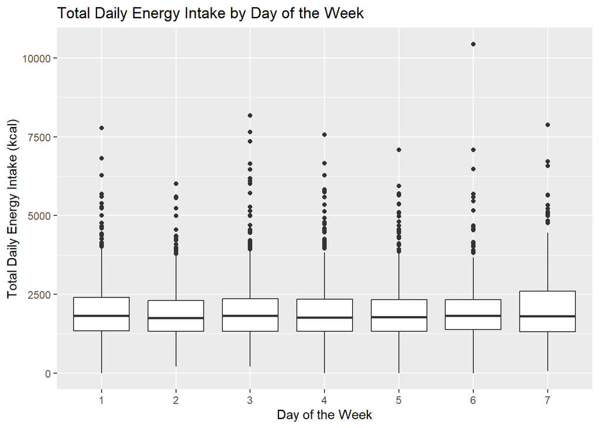

```r
# Visualize the data as is
ggplot(df, aes(x = factor(day_of_week), y = total_kcal)) +
  geom_boxplot() +
  labs(
    title = "Total Daily Energy Intake by Day of the Week",
    x = "Day of the Week",
    y = "Total Daily Energy Intake (kcal)"
  )
```

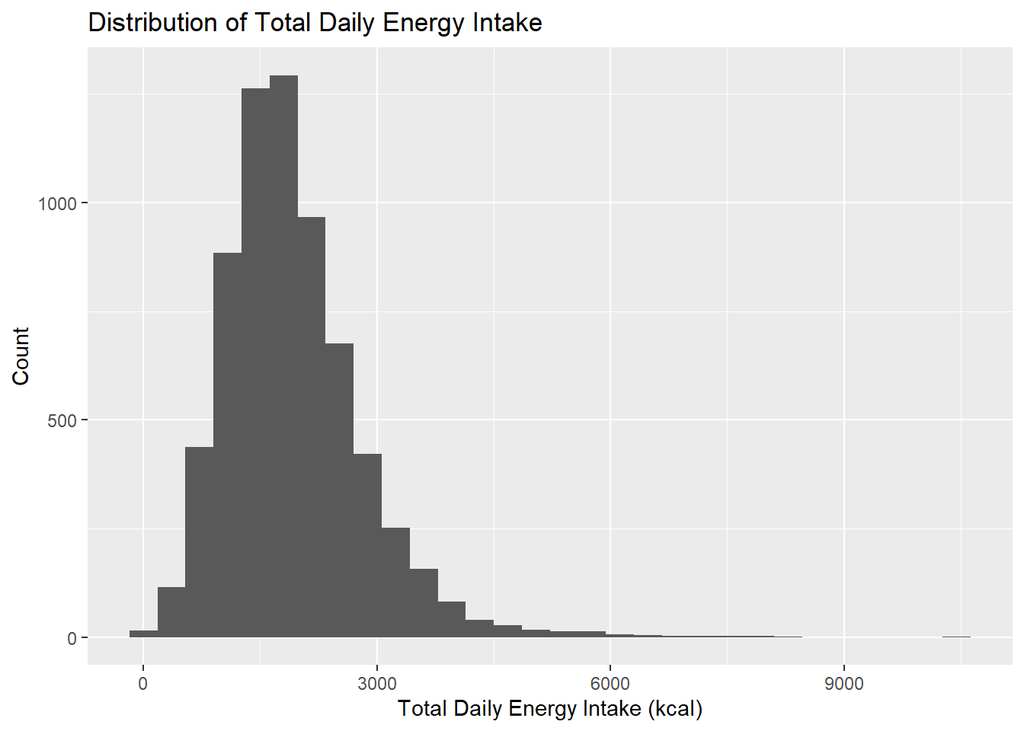

```r
ggplot(df, aes(x = total_kcal)) +
  geom_histogram(bins = 30) +
  labs(
    title = "Distribution of Total Daily Energy Intake",
    x = "Total Daily Energy Intake (kcal)",
    y = "Count"
  )
```

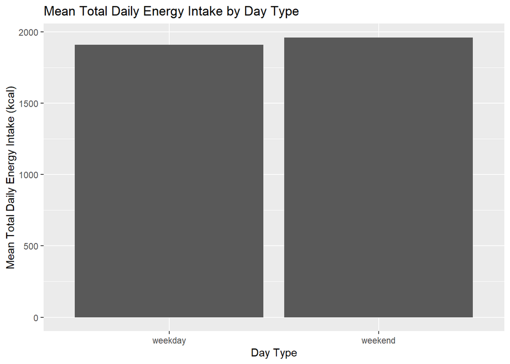

```r
# Calculate means by `weekend`
df_means <- df |>
  group_by(weekend) |>
  summarise(
    n = n(),
    mean_kcal = mean(total_kcal, na.rm = TRUE),
    median_kcal = median(total_kcal, na.rm = TRUE),
    iqr_kcal = IQR(total_kcal, na.rm = TRUE),
    min_kcal = min(total_kcal, na.rm = TRUE),
    max_kcal = max(total_kcal, na.rm = TRUE)
  )

# Visualize Mean data
ggplot(df_means, aes(x = weekend, y = mean_kcal)) +
  geom_col() +
  labs(
    title = "Mean Total Daily Energy Intake by Day Type",
    x = "Day Type",
    y = "Mean Total Daily Energy Intake (kcal)"
  )
```

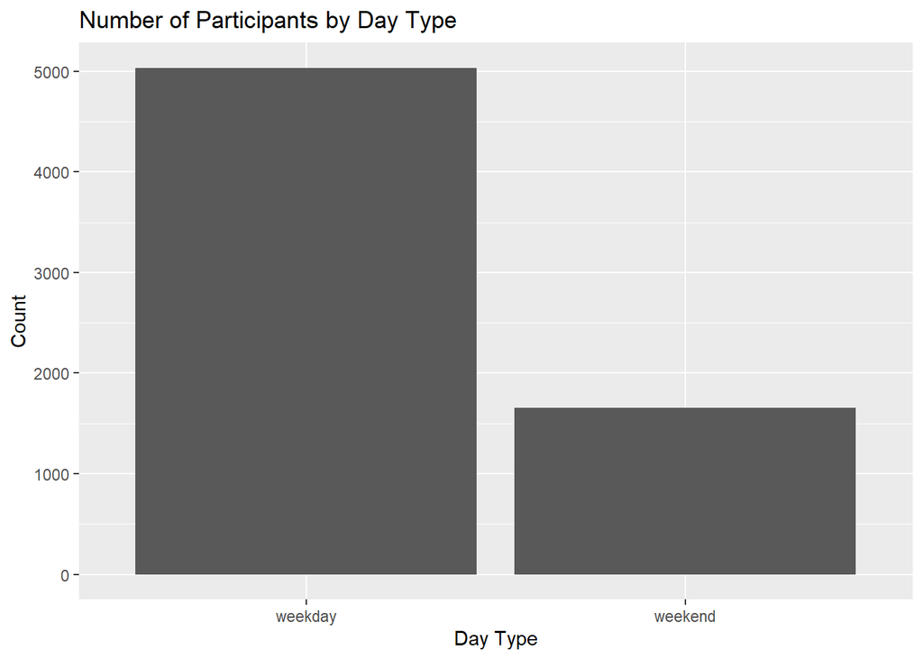

```r
ggplot(df_means, aes(x = weekend, y = n)) +
  geom_col() +
  labs(
    title = "Number of Participants by Day Type",
    x = "Day Type",
    y = "Count"
  )
```